# Befolkningsutvecklingen i Hedemora

Befolkningsutvecklingen i Hedemora  
- en kort analys

Rapporten är skapad av Samhällsanalys, Region Dalarna  
Senast uppdaterad: 2026-05-16

# Sammanfattning

Syftet med den här korta analysen är att undersöka Hedemoras befolkningsutveckling. Ett antal viktiga slutsatser sammanfattas här:

- Den stora minsknigen i Hedemoras folkmängd år 2025, beror i första hand på en kombination av låga födelsetal och stor inrikes utflyttning (netto). Dessutom invandrar få till kommunen.
- Det föddes färre barn i Hedemora år 2025, jämfört med åren innan. Sjunkande födelsetal är en nationell trend men också en trend i de flesta av världens utvecklade länder.
- En stramare nationell migrationspolitik gör att färre invandrar till Sverige än tidigare, vilket även påverkar inflyttningen till Hedemora.

För mer info om statistiken, klicka på rutan nedan:

**Mer information om statistiken**

I folkmängden som SCB publicerar ingår personer som är folkbokförda i landet. För att den som flyttar till Sverige ska bli folkbokförd ska personen ha för avsikt och rätt att stanna i Sverige i minst ett år. För personer som inte är medborgare i ett EU-land innebär det att det krävs ett uppehållstillstånd som gäller minst 12 månader för att bli folkbokförd. Till följd av Rysslands invasion av Ukraina den 24 februari 2022 har Europeiska unionen (EU) beslutat att aktivera massflyktsdirektivet, vilket innebär att personer från Ukraina utan individuell prövning ska erbjudas tidsbegränsat uppehålls- och arbetstillstånd inom EU. Personer som får uppehållstillstånd enligt massflyktsdirektivet ska i regel inte bli folkbokförda och ingå i den officiella befolkningsstatistiken. Läs mer här. Sedan juni 2024 har dock personer födda i Ukraina haft möjlighet att ansöka om att bli folkbokförda i Sverige (SCB).

Under 2023 inledde Skatteverket ett arbete med att granska registret över folkbokförda. Det förde med sig att SCB avregistrerade flera tusen folkbokförda personer som visade sig inte längre bo i Sverige. I folkbokföringen har dessa registrerats som utvandrade till okänt utvandringsland. Detta arbete fortsatte under 2024. Läs mer [här](https://www.scb.se/pressmeddelande/sverige-gar-mot-lagsta-befolkningsokningen-pa-manga-ar/).

All data som används i rapporten är offentlig och finns under kategorin befolkning i SCB:s [Statistikdatabas](https://www.statistikdatabasen.scb.se/pxweb/sv/ssd/). Där finns även data för exempelvis befolkningsutvecklingen under 2025 på månadsbasis som publiceras löpande, något som inte behandlas i denna rapport.

Från och med referensåret 2025 och framåt är en liten kontrollerad slumpmässig osäkerhet införd i samtliga redovisade uppgifter. Osäkerheten har tillförts för att skydda enskilda personer så att ingen riskerar att röjas i statistiken. Till följd av detta så är inte alltid de redovisade totalerna lika med summan av deras redovisade delar.

Om redovisade statistikvärden adderas för att skapa en ny total, så adderas även osäkerheten. Det finns därför risk för att den nya totalen innehåller större osäkerhet än vad som, enligt metoden, skulle ha tillförts ett enskilt statistikvärde.

Metoden som används för röjandekontroll heter Cell Key Method (CKM). Du kan läsa mer om metoden här: [Skyddsmetoder för röjandekontroll](https://www.scb.se/dokumentation/statistiska-metoder/skyddsmetoder-for-rojandekontroll/) och här: [utveckling av röjandeskyddet](https://www.scb.se/dokumentation/statistikomraden-under-forandring/utveckling-av-rojandeskyddet/), samt i befolkningsstatistikens dokumentation (kvalitetsdeklarationen, avsnitt 2.2.6).

FAQ om CKM-metoden hittar du här: [Frågor och svar om röjandeskydd i befolkningsstatistiken](https://www.scb.se/FAQ-CKM)

# 1 Hur har befolkningen förändrats?

I likhet med flera bruksorter i de södra delarna av Dalarna har folkmängden i Hedemora minskat på lång sikt, från ca 17 400 invånare år 1968 till ungefär 15 000 invånare år 2025.

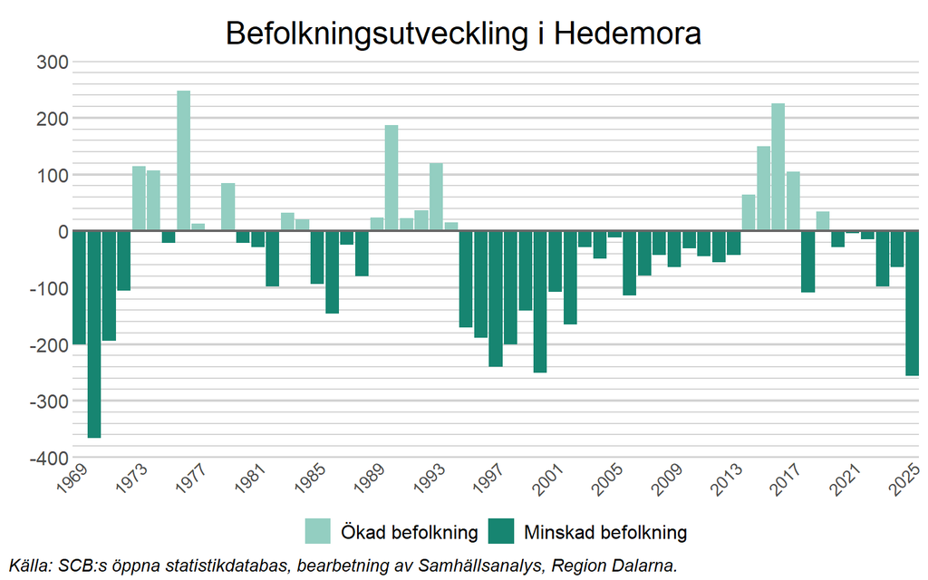

I fortsättningen av denna korta analys delas befolkningsutveckling upp i dess komponenter, födelsenetto, dvs. nettot av födda och döda, och flyttnetto, dvs. nettot av inrikes och utrikes flyttar.

# 2 Födelsenetto

En trend är att det dör färre personer i Hedemora idag än det gjorde längre tillbaka i tiden. På senare år har runt 170-190 personer dött årligen i kommunen, att jämföra med över 200 personer per år i början av 2000-talet. Denna utveckling härrör sannolikt till utveckling inom det medicinska området. Befolkningens medelålder ökar över tid och har gjort så länge.

Även när det gäller antalet födslar är trenden negativ. Under tidigt 1990-tal föddes ofta runt 250 barn i Hedemora per år, men en tydlig negativ trend inleddes i samband med finanskrisen i början på 1990-talet. Under 2010-talet ökade födslarna igen, något som sannolikt har att göra med att Hedemoras befolkning då ökade till följd av högre invandring. År 2025 föddes ungefär 100 barn, vilket var färre än åren innan.

Med undantag för 2020, har nettot mellan födda och döda, se de svarta linjerna i diagrammet nedan, varit negativt i Hedemora under varje år sedan början av 1990-talet. Hur många invånare som kommunen tappar på grund av det varierar relativt mycket mellan åren, men det har skett en tydlig ökning på senare år.

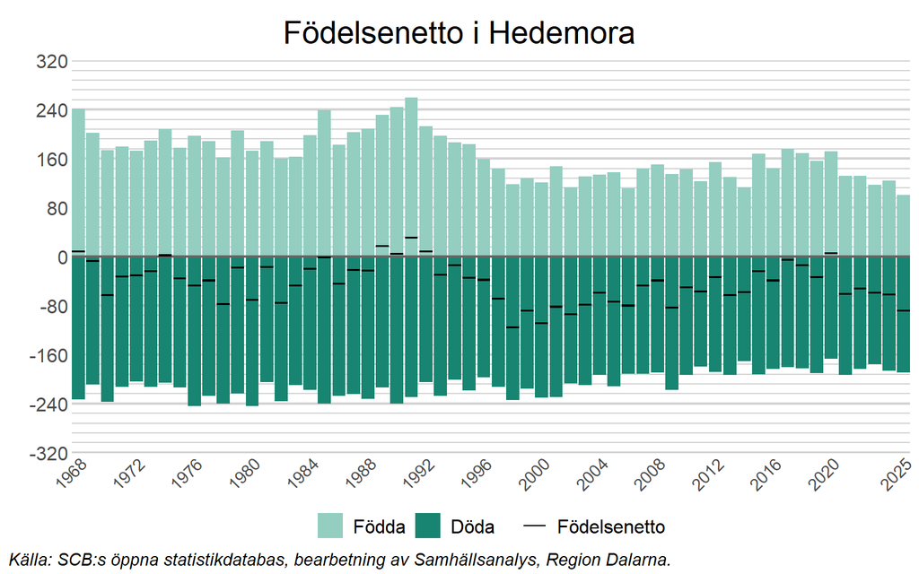

# 3 Flyttnetto

Den andra komponenten som styr befolkningsutvecklingen är det så kallade flyttnettot. Detta kan i sin tur delas upp i två komponenter, inrikes och utrikes flyttar. I det här avsnittet är fokus först på flyttnettot, innan de två komponenterna undersöks.

Nettot mellan antalet personer som flyttar till och från Hedemora varierar relativt mycket mellan åren, men har på senare år ofta varit +/- 50 personer. Undantagen var några år i mitten på 2010-talet, när mer än 500 personer netto flyttade till kommunen mellan 2014 och 2016, samt 2025 när flyttnettot var klart mer negativt än normalt.

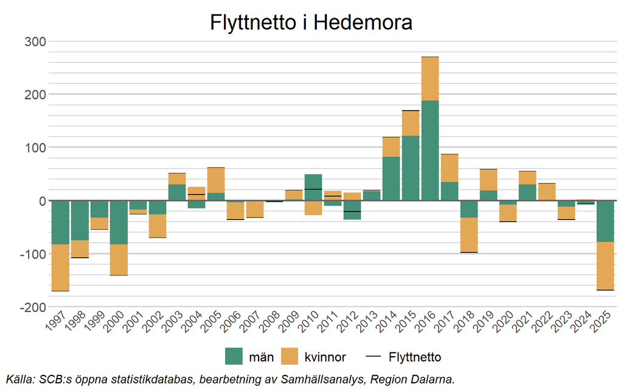

## 3.1 Utrikes flyttnetto

Som vi berörde i föregående avsnitt flyttade många till Hedemora under några år i mitten på 2010-talet, vilket till stor del kan förklaras av att invandringen då var stor. I slutet av 1990-talet var invandringen ofta väldigt låg och till och med negativ under vissa år (fler utvandrade än invandrade), men därefter skedde en gradvis ökning innan den stora toppen 2016. Därefter minskade invandringen tydligt, men låg på relativt höga nivåer fram till 2019. På senare år syns effekterna av en tydligt stramare nationell migrationspolitik, då allt färre invandrar till Hedemora. Under 2025 var det utrikes flyttnettot runt 20 personer, vilket var något lägre än året innan än men högre än 2023. Att det utrikes flyttnettot ökat 2024 och 2025, jämfört med 2023, beror sannolikt delvis på att personer födda i Ukraina sedan juni 2024 haft möjlighet att ansöka om att bli folkbokförda i Sverige, vilket medfört att antalet personer födda i Ukraina ökat med drygt 15 personer i Hedemora sedan 2023 (se [SCB](https://www.statistikdatabasen.scb.se/pxweb/sv/ssd/START__BE__BE0101__BE0101E/FolkmRegFlandK/table/tableViewLayout1/) och [SCB](https://www.statistikdatabasen.scb.se/pxweb/sv/ssd/START__BE__BE0101__BE0101E/FodelselandArKCKM/)). Läs mer i den klickbara rutan “mer information om statistiken” ovan.

Viktigt att notera är också att de avregistreringar av utvandrade som Skattemyndigheten påbörjade under 2023 (se informationsrutan under avsnittet introduktion ovan) påverkade utvandringen under åtminstone 2023 och 2024.

Generellt invandrar ungefär lika många kvinnor och män till Hedemora.

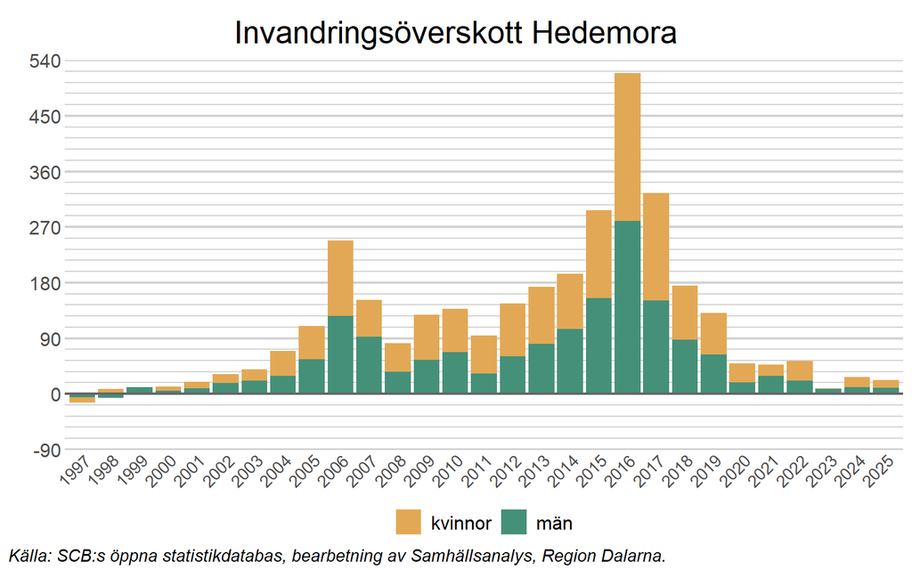

## 3.2 Inrikes flyttnetto

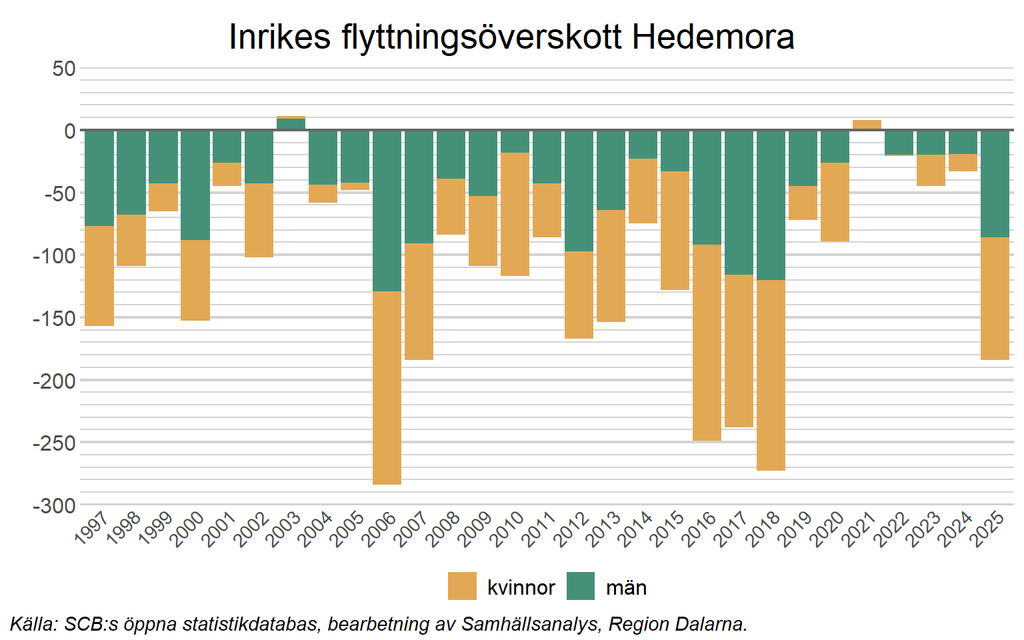

I nästa avsnitt blickar vi istället framåt. Hur kommer Hedemoras folkmängd att utvecklas fram till 2034?

# 4 Vad händer i framtiden?

*Notera att prognosen nedan gjordes våren 2025. Avsnittet kommer därför att uppdateras med en ny prognos under våren 2026.*

För en djupare förståelse runt hur Region Dalarna gör befolkningsprognoser, se motsvarande avsnitt i rapporten för hela Dalarnas län. Det viktigaste att ha i åtanke är att ingen hänsyn tas i prognoserna till exempelvis företagsetableringar eller andra framtida mål och förutsättningar som kommunerna har i sina planer.

I diagrammet nedan visas befolkningsutvecklingen i Hedemora fram till 2034 uppdelat på åldersgrupper, enligt Region Dalarnas prognos från våren 2025.

- Folkmängden i Hedemora prognostiseras att minska till 14 640 personer år 2034, en minskning med ungefär 640 personer jämfört med 2024. I SCB:s senaste prognos (juni 2024), prognostiserades en befolkning på knappt 14 720 personer i Hedemora år 2034 (se [SCB, 2024](https://www.statistikdatabasen.scb.se/pxweb/sv/ssd/START__BE__BE0401__BE0401A/BefProgRegFakN/)).
- Den största minskningen sker i åldersgruppen som brukar benämnas arbetsför ålder, 20-65 år, som prognostiseras minska med ungefär 600 personer.
- I åldergruppen 80+ förväntas befolkning att öka med ungefär 360 personer fram till 2034. Detta hänger sannolikt samman med att den förväntade livslängden fortsätter öka och att den stora gruppen “baby-boomers” börjar komma upp i 80-års åldern.
- Även i åldersgruppen 0-19 år sker en relativt stor minskning av befolkningen, ungefär 450 personer.

[figure not shown]